# 勞動部家庭外籍看護工管理及運用調查分析

資料時間：113年6月｜家庭面調查表

分析報告

2026-05-03

# 0. 套件載入與資料讀取

> 本報告使用勞動部「移工管理及運用調查」113年家庭面問卷資料（N = 4,016）， 著重於**家庭內移工**的交互作用分析，探討不同背景移工的逃跑風險、 雇主困擾差異、以及滿意度偏見等議題。

```r
# ---- 請確認已安裝以下套件，若未安裝請先執行 install.packages() ----
library(tidyverse)    # 資料處理與視覺化核心
library(scales)       # 格式化標籤
# library(ggmosaic)     # 馬賽克圖（交叉分析）
library(patchwork)    # 多圖拼接
library(broom)        # 模型整理
library(knitr)        # 表格輸出
library(RColorBrewer) # 色票
library(ggplot2)

# 設定中文字型（依系統而異，macOS 可用 "PingFang TC"；Windows 可用 "Microsoft JhengHei"）
theme_set(
  theme_minimal(base_family = "Microsoft JhengHei", base_size = 13) +
    theme(
      plot.title = element_text(face = "bold", size = 16),
      plot.subtitle = element_text(color = "grey40"),
      legend.position = "bottom"
    )
)

# 色票設定（全域共用）
pal_nation <- c("印尼" = "#E74C3C", "菲律賓" = "#3498DB",
                "泰國" = "#2ECC71", "越南" = "#F39C12")
pal_gender <- c("男" = "#5DADE2", "女" = "#F1948A")
pal_sat    <- brewer.pal(5, "RdYlGn")[5:1]  # 很滿意→很不滿意
```

```r
# ---- 讀取資料 ----
# 📌 請將 data113.csv 放在與本 .Rmd 相同的資料夾，或修改下方路徑
raw <- read_csv("data113.csv", locale = locale(encoding = "UTF-8"),
                show_col_types = FALSE)
cat("原始資料：", nrow(raw), "筆觀測，", ncol(raw), "個欄位\n")
```

```
## 原始資料： 4016 筆觀測， 117 個欄位
```

# 1. 資料清理與變項編碼

> 以下將問卷代碼轉換為有意義的中文標籤，方便後續分析與圖表呈現。

```r
df <- raw %>%
  mutate(
    # ===== 移工基本資料（Q8）=====
    性別 = factor(q8a, levels = 1:2, labels = c("男", "女")),

    年齡組 = factor(q8b, levels = 1:4,
                   labels = c("未滿25歲", "25-34歲", "35-44歲", "45歲以上")),

    教育程度 = factor(q8c, levels = 1:3,
                    labels = c("國中及以下", "高中(職)", "專科及以上")),

    國籍 = factor(q8d, levels = 1:4,
                 labels = c("印尼", "菲律賓", "泰國", "越南")),

    護理訓練 = factor(q8e, levels = 1:2, labels = c("有", "無")),

    # ===== 逃跑（Q5）=====
    曾逃跑 = factor(q5, levels = 1:2, labels = c("否", "是")),

    # ===== 僱用困擾（Q6）=====
    有困擾 = factor(q6, levels = 1:2, labels = c("無", "有")),

    # ===== 家庭經濟（Q7）=====
    家庭經濟 = factor(q7, levels = 1:3,
                    labels = c("一般戶", "中低收入戶", "低收入戶")),

    # ===== 薪資支付方式（Q11）=====
    薪資支付 = factor(q11, levels = 1:5,
                    labels = c("現金", "匯入銀行", "部分現金部分匯款",
                               "交仲介處理", "其他")),

    # ===== 薪資明細（Q12）=====
    薪資明細 = factor(q12, levels = 1:3,
                    labels = c("有（中文及母國文字）",
                               "有（僅中文）",
                               "沒有")),

    # ===== 放假（Q13a）=====
    放假情形 = factor(q13a, levels = 1:5,
                    labels = c("都有放假(4-5次)", "1次", "2-3次",
                               "其他", "都不放假")),

    # ===== 家人同住（Q14）=====
    家人同住 = factor(q14, levels = 1:2, labels = c("有", "無")),

    # ===== 輪替照顧（Q15）=====
    有輪替 = factor(q15, levels = 1:2, labels = c("有", "無")),

    # ===== 願意讓移工休假（Q17）=====
    願意休假 = factor(q17, levels = 1:3,
                    labels = c("願意", "不願意", "不確定")),

    # ===== 意外保險（Q19）=====
    有保險 = factor(q19, levels = 1:2, labels = c("有", "無")),

    # ===== 曾僱本國看護（Q4）=====
    曾僱本國 = factor(q4, levels = 1:2, labels = c("沒有", "有")),

    # ===== 知道仲介評鑑（Q22）=====
    知道評鑑 = factor(q22, levels = 1:2, labels = c("知道", "不知道")),

    # ===== 願意參加講習（Q21）=====
    願意講習 = factor(q21, levels = 1:2, labels = c("願意", "不願意")),

    # ===== 僱用前照顧方式（Q2）=====
    僱前照顧 = factor(q2, levels = 1:6,
                    labels = c("由家人照顧", "找本國看護",
                               "老人福利機構等", "請親友照顧",
                               "找本國幫傭", "其他")),

    # ===== 連續變項 =====
    月薪 = as.numeric(nq10a),
    加班費 = as.numeric(nq10ab),
    每日工時 = as.numeric(nq9b_1) + as.numeric(nq9b_2) / 60,
    權重 = as.numeric(w)
  )

# ===== 滿意度量表（Q20）：轉為長格式 =====
sat_labels <- c(
  q20_1 = "看護技術", q20_2 = "工作態度", q20_3 = "工作情緒",
  q20_4 = "工作效率", q20_5 = "僱傭關係", q20_6 = "衛生習慣",
  q20_7 = "整體表現"
)

df_sat <- df %>%
  select(no, 國籍, 性別, 年齡組, 教育程度, 權重,
         q20_1:q20_7) %>%
  pivot_longer(cols = q20_1:q20_7,
               names_to = "面向", values_to = "滿意度分數") %>%
  mutate(
    面向 = recode(面向, !!!sat_labels),
    滿意度分數 = as.numeric(滿意度分數),
    滿意度 = factor(滿意度分數, levels = 1:5,
                   labels = c("很滿意", "滿意", "普通", "不滿意", "很不滿意"))
  ) %>%
  filter(!is.na(滿意度分數))

# ===== 困擾原因（Q6a）：轉為長格式 =====
trouble_labels <- c(
  q6a_1 = "語言不通", q6a_2 = "溝通困難", q6a_3 = "愛滑手機",
  q6a_4 = "態度/紀律不佳", q6a_5 = "照顧技術不佳",
  q6a_6 = "衛生習慣不佳", q6a_7 = "生活環境不適應",
  q6a_8 = "有偷竊行為", q6a_9 = "要求調薪",
  q6a_10 = "要求轉換雇主", q6a_11 = "其他"
)

df_trouble <- df %>%
  filter(有困擾 == "有") %>%
  select(no, 國籍, 性別, 年齡組, 權重, q6a_1:q6a_11) %>%
  pivot_longer(cols = q6a_1:q6a_11,
               names_to = "困擾項目", values_to = "有勾選") %>%
  mutate(
    困擾項目 = recode(困擾項目, !!!trouble_labels),
    有勾選 = as.numeric(有勾選)
  )

# ===== 逃跑原因（Q5a）：轉為長格式 =====
runaway_labels <- c(
  q5a_1 = "受他人慫恿/轉介", q5a_2 = "希望較高待遇",
  q5a_3 = "聘僱期將屆滿", q5a_4 = "賭博欠債/犯法",
  q5a_5 = "相處不融洽", q5a_6 = "工作/生活不適應",
  q5a_7 = "仲介服務費太高", q5a_8 = "勞資爭議",
  q5a_9 = "其他"
)

df_runaway <- df %>%
  filter(曾逃跑 == "是") %>%
  select(no, 國籍, 性別, 年齡組, 權重, q5a_1:q5a_9) %>%
  pivot_longer(cols = q5a_1:q5a_9,
               names_to = "逃跑原因", values_to = "有勾選") %>%
  mutate(
    逃跑原因 = recode(逃跑原因, !!!runaway_labels),
    有勾選 = as.numeric(有勾選)
  )

cat("清理完成！有效分析樣本數：", nrow(df), "\n")
```

```
## 清理完成！有效分析樣本數： 4016
```

# 2. 移工基本人口特徵

## 2.1 國籍 × 性別分布

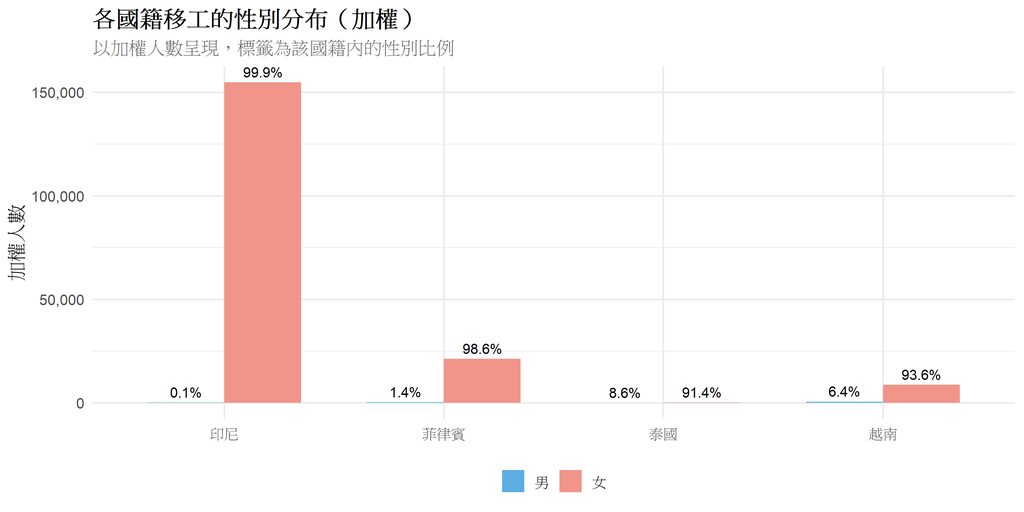

```r
df %>%
  filter(!is.na(國籍), !is.na(性別)) %>%
  count(國籍, 性別, wt = 權重) %>%
  group_by(國籍) %>%
  mutate(pct = n / sum(n)) %>%
  ggplot(aes(x = 國籍, y = n, fill = 性別)) +
  geom_col(position = "dodge", width = 0.7) +
  geom_text(aes(label = percent(pct, accuracy = 0.1)),
            position = position_dodge(0.7), vjust = -0.5, size = 3.5) +
  scale_fill_manual(values = pal_gender) +
  scale_y_continuous(labels = comma) +
  labs(title = "各國籍移工的性別分布（加權）",
       subtitle = "以加權人數呈現，標籤為該國籍內的性別比例",
       x = NULL, y = "加權人數") +
  theme(legend.title = element_blank())
```

## 2.2 年齡 × 國籍分布

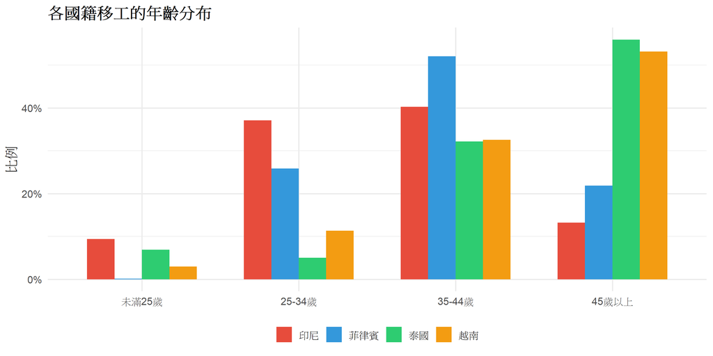

```r
df %>%
  filter(!is.na(國籍), !is.na(年齡組)) %>%
  count(國籍, 年齡組, wt = 權重) %>%
  group_by(國籍) %>%
  mutate(pct = n / sum(n)) %>%
  ggplot(aes(x = 年齡組, y = pct, fill = 國籍)) +
  geom_col(position = "dodge", width = 0.7) +
  scale_fill_manual(values = pal_nation) +
  scale_y_continuous(labels = percent) +
  labs(title = "各國籍移工的年齡分布",
       x = NULL, y = "比例") +
  theme(legend.title = element_blank())
```

## 2.3 教育程度 × 國籍

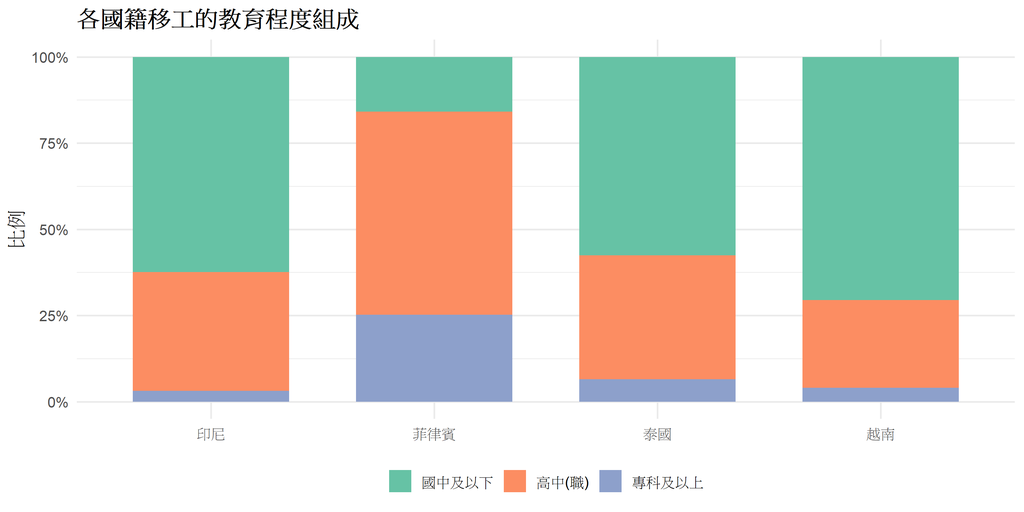

```r
df %>%
  filter(!is.na(國籍), !is.na(教育程度)) %>%
  count(國籍, 教育程度, wt = 權重) %>%
  group_by(國籍) %>%
  mutate(pct = n / sum(n)) %>%
  ggplot(aes(x = 國籍, y = pct, fill = 教育程度)) +
  geom_col(width = 0.7) +
  scale_y_continuous(labels = percent) +
  scale_fill_brewer(palette = "Set2") +
  labs(title = "各國籍移工的教育程度組成",
       x = NULL, y = "比例") +
  theme(legend.title = element_blank())
```

## 2.4 護理訓練 × 國籍

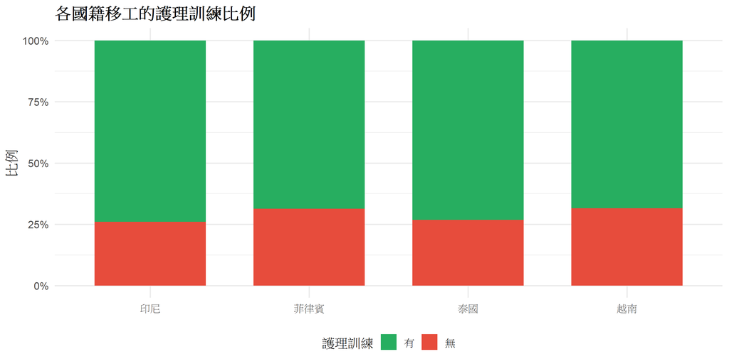

```r
df %>%
  filter(!is.na(國籍), !is.na(護理訓練)) %>%
  count(國籍, 護理訓練, wt = 權重) %>%
  group_by(國籍) %>%
  mutate(pct = n / sum(n)) %>%
  ggplot(aes(x = 國籍, y = pct, fill = 護理訓練)) +
  geom_col(width = 0.7) +
  scale_y_continuous(labels = percent) +
  scale_fill_manual(values = c("有" = "#27AE60", "無" = "#E74C3C")) +
  labs(title = "各國籍移工的護理訓練比例",
       x = NULL, y = "比例")
```

# 3. 逃跑行為分析（交互作用重點）

> **核心問題：什麼樣的移工最常逃跑？** 以下從國籍、性別、年齡、教育程度等面向進行交叉分析。

## 3.1 逃跑率：依國籍

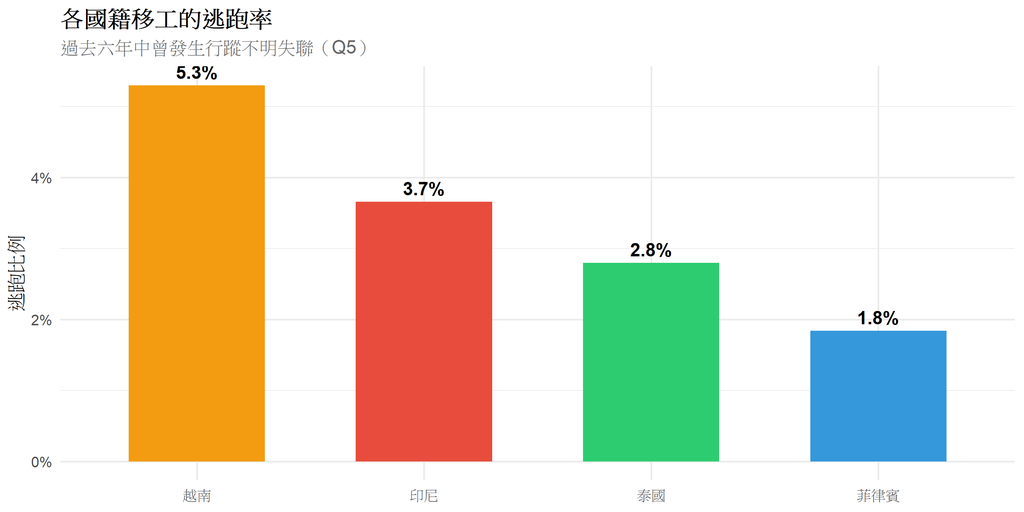

```r
df %>%
  filter(!is.na(國籍), !is.na(曾逃跑)) %>%
  count(國籍, 曾逃跑, wt = 權重) %>%
  group_by(國籍) %>%
  mutate(pct = n / sum(n)) %>%
  filter(曾逃跑 == "是") %>%
  ggplot(aes(x = reorder(國籍, -pct), y = pct, fill = 國籍)) +
  geom_col(width = 0.6, show.legend = FALSE) +
  geom_text(aes(label = percent(pct, accuracy = 0.1)),
            vjust = -0.5, fontface = "bold") +
  scale_fill_manual(values = pal_nation) +
  scale_y_continuous(labels = percent, limits = c(0, NA)) +
  labs(title = "各國籍移工的逃跑率",
       subtitle = "過去六年中曾發生行蹤不明失聯（Q5）",
       x = NULL, y = "逃跑比例")
```

## 3.2 逃跑率：國籍 × 性別（交互作用）

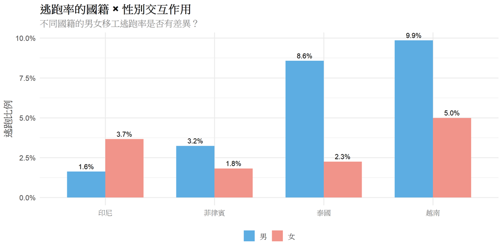

```r
df %>%
  filter(!is.na(國籍), !is.na(性別), !is.na(曾逃跑)) %>%
  count(國籍, 性別, 曾逃跑, wt = 權重) %>%
  group_by(國籍, 性別) %>%
  mutate(pct = n / sum(n)) %>%
  filter(曾逃跑 == "是") %>%
  ggplot(aes(x = 國籍, y = pct, fill = 性別)) +
  geom_col(position = "dodge", width = 0.7) +
  geom_text(aes(label = percent(pct, accuracy = 0.1)),
            position = position_dodge(0.7), vjust = -0.5, size = 3.5) +
  scale_fill_manual(values = pal_gender) +
  scale_y_continuous(labels = percent) +
  labs(title = "逃跑率的國籍 × 性別交互作用",
       subtitle = "不同國籍的男女移工逃跑率是否有差異？",
       x = NULL, y = "逃跑比例") +
  theme(legend.title = element_blank())
```

## 3.3 逃跑率：國籍 × 年齡組（交互作用）

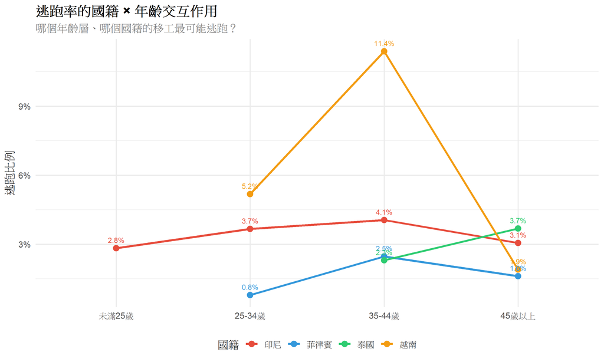

```r
df %>%
  filter(!is.na(國籍), !is.na(年齡組), !is.na(曾逃跑)) %>%
  count(國籍, 年齡組, 曾逃跑, wt = 權重) %>%
  group_by(國籍, 年齡組) %>%
  mutate(pct = n / sum(n)) %>%
  filter(曾逃跑 == "是") %>%
  ggplot(aes(x = 年齡組, y = pct, color = 國籍, group = 國籍)) +
  geom_line(linewidth = 1.2) +
  geom_point(size = 3) +
  geom_text(aes(label = percent(pct, accuracy = 0.1)),
            vjust = -1, size = 3, show.legend = FALSE) +
  scale_color_manual(values = pal_nation) +
  scale_y_continuous(labels = percent) +
  labs(title = "逃跑率的國籍 × 年齡交互作用",
       subtitle = "哪個年齡層、哪個國籍的移工最可能逃跑？",
       x = NULL, y = "逃跑比例")
```

## 3.4 逃跑率：國籍 × 教育程度

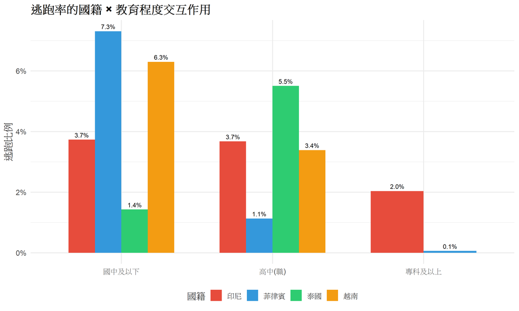

```r
df %>%
  filter(!is.na(國籍), !is.na(教育程度), !is.na(曾逃跑)) %>%
  count(國籍, 教育程度, 曾逃跑, wt = 權重) %>%
  group_by(國籍, 教育程度) %>%
  mutate(pct = n / sum(n)) %>%
  filter(曾逃跑 == "是") %>%
  ggplot(aes(x = 教育程度, y = pct, fill = 國籍)) +
  geom_col(position = "dodge", width = 0.7) +
  geom_text(aes(label = percent(pct, accuracy = 0.1)),
            position = position_dodge(0.7), vjust = -0.5, size = 3) +
  scale_fill_manual(values = pal_nation) +
  scale_y_continuous(labels = percent) +
  labs(title = "逃跑率的國籍 × 教育程度交互作用",
       x = NULL, y = "逃跑比例")
```

## 3.5 逃跑的 Logistic 迴歸（含交互項）

```r
# 建立逃跑的二元變項
df <- df %>%
  mutate(逃跑_二元 = ifelse(曾逃跑 == "是", 1, 0))

# 主效果模型
model_main <- glm(逃跑_二元 ~ 國籍 + 性別 + 年齡組 + 教育程度 + 護理訓練 + 月薪,
                  data = df, family = binomial, weights = 權重)

# 含交互項模型：國籍 × 性別、國籍 × 年齡組
model_inter <- glm(逃跑_二元 ~ 國籍 * 性別 + 國籍 * 年齡組 + 教育程度 + 護理訓練 + 月薪,
                   data = df, family = binomial, weights = 權重)

cat("===== 主效果模型 =====\n")
```

```
## ===== 主效果模型 =====
```

```r
tidy(model_main, conf.int = TRUE, exponentiate = TRUE) %>%
  mutate(across(where(is.numeric), ~ round(., 3))) %>%
  kable(caption = "逃跑 Logistic 迴歸 — 主效果（勝算比 OR）")
```

逃跑 Logistic 迴歸 — 主效果（勝算比 OR）

| term | estimate | std.error | statistic | p.value | conf.low | conf.high |
| --- | --- | --- | --- | --- | --- | --- |
| (Intercept) | 0.194 | 0.225 | -7.296 | 0.000 | 0.125 | 0.301 |
| 國籍菲律賓 | 0.575 | 0.055 | -10.054 | 0.000 | 0.515 | 0.639 |
| 國籍泰國 | 1.228 | 0.394 | 0.521 | 0.602 | 0.512 | 2.460 |
| 國籍越南 | 1.607 | 0.052 | 9.049 | 0.000 | 1.448 | 1.779 |
| 性別女 | 0.545 | 0.127 | -4.790 | 0.000 | 0.428 | 0.704 |
| 年齡組25-34歲 | 1.354 | 0.055 | 5.484 | 0.000 | 1.217 | 1.511 |
| 年齡組35-44歲 | 1.680 | 0.054 | 9.516 | 0.000 | 1.511 | 1.871 |
| 年齡組45歲以上 | 0.999 | 0.064 | -0.011 | 0.991 | 0.882 | 1.134 |
| 教育程度高中(職) | 0.866 | 0.028 | -5.162 | 0.000 | 0.819 | 0.914 |
| 教育程度專科及以上 | 0.290 | 0.103 | -12.083 | 0.000 | 0.235 | 0.352 |
| 護理訓練無 | 1.601 | 0.027 | 17.719 | 0.000 | 1.520 | 1.686 |
| 月薪 | 1.000 | 0.000 | -7.866 | 0.000 | 1.000 | 1.000 |

```r
cat("\n===== 含交互項模型 =====\n")
```

```
##
## ===== 含交互項模型 =====
```

```r
tidy(model_inter, conf.int = TRUE, exponentiate = TRUE) %>%
  mutate(across(where(is.numeric), ~ round(., 3))) %>%
  kable(caption = "逃跑 Logistic 迴歸 — 含交互項（勝算比 OR）")
```

逃跑 Logistic 迴歸 — 含交互項（勝算比 OR）

| term | estimate | std.error | statistic | p.value | conf.low | conf.high |
| --- | --- | --- | --- | --- | --- | --- |
| (Intercept) | 0.046 | 0.602 | -5.110 | 0.000 | 1.100000e-02 | 1.290000e-01 |
| 國籍菲律賓 | 0.000 | 1659.848 | -0.009 | 0.993 | 0.000000e+00 | 0.000000e+00 |
| 國籍泰國 | 0.000 | 417.629 | -0.023 | 0.982 | 0.000000e+00 | 0.000000e+00 |
| 國籍越南 | 0.000 | 54.612 | -0.171 | 0.864 | 0.000000e+00 | 0.000000e+00 |
| 性別女 | 2.266 | 0.572 | 1.430 | 0.153 | 8.750000e-01 | 8.897000e+00 |
| 年齡組25-34歲 | 1.361 | 0.055 | 5.559 | 0.000 | 1.222000e+00 | 1.519000e+00 |
| 年齡組35-44歲 | 1.536 | 0.055 | 7.799 | 0.000 | 1.381000e+00 | 1.713000e+00 |
| 年齡組45歲以上 | 1.136 | 0.066 | 1.941 | 0.052 | 9.990000e-01 | 1.293000e+00 |
| 教育程度高中(職) | 0.871 | 0.028 | -4.943 | 0.000 | 8.240000e-01 | 9.200000e-01 |
| 教育程度專科及以上 | 0.293 | 0.103 | -11.980 | 0.000 | 2.380000e-01 | 3.560000e-01 |
| 護理訓練無 | 1.579 | 0.027 | 17.153 | 0.000 | 1.499000e+00 | 1.664000e+00 |
| 月薪 | 1.000 | 0.000 | -7.624 | 0.000 | 1.000000e+00 | 1.000000e+00 |
| 國籍菲律賓:性別女 | 0.192 | 0.660 | -2.504 | 0.012 | 4.400000e-02 | 6.340000e-01 |
| 國籍泰國:性別女 | 0.066 | 1.083 | -2.509 | 0.012 | 8.000000e-03 | 6.800000e-01 |
| 國籍越南:性別女 | 0.217 | 0.593 | -2.576 | 0.010 | 5.400000e-02 | 5.950000e-01 |
| 國籍菲律賓:年齡組25-34歲 | 1943890.665 | 1659.848 | 0.009 | 0.993 | 0.000000e+00 | 2.180013e+236 |
| 國籍泰國:年齡組25-34歲 | 1.556 | 472.962 | 0.001 | 0.999 | 0.000000e+00 | 4.035000e+00 |
| 國籍越南:年齡組25-34歲 | 63448.671 | 54.609 | 0.202 | 0.840 | 3.136048e+35 | 1.263190e+32 |
| 國籍菲律賓:年齡組35-44歲 | 5191966.037 | 1659.848 | 0.009 | 0.993 | 0.000000e+00 | 2.852911e+234 |
| 國籍泰國:年齡組35-44歲 | 121220.365 | 417.629 | 0.028 | 0.978 | 5.805947e+239 | 7.729270e+213 |
| 國籍越南:年齡組35-44歲 | 148080.065 | 54.609 | 0.218 | 0.827 | 2.245451e+04 | 1.119176e+14 |
| 國籍菲律賓:年齡組45歲以上 | 4853827.713 | 1659.848 | 0.009 | 0.993 | 0.000000e+00 | 1.121154e+235 |
| 國籍泰國:年齡組45歲以上 | 275851.975 | 417.629 | 0.030 | 0.976 | 0.000000e+00 | NA |
| 國籍越南:年齡組45歲以上 | 32876.901 | 54.609 | 0.190 | 0.849 | 2.393631e+35 | 5.300663e+31 |

```r
# 模型比較（LRT）
cat("\n===== 模型比較（概似比檢定）=====\n")
```

```
##
## ===== 模型比較（概似比檢定）=====
```

```r
anova(model_main, model_inter, test = "Chisq")
```

|  | Resid. Df | Resid. Dev | Df | Deviance | Pr(>Chi) |
| --- | --- | --- | --- | --- | --- |
| 1 | 4004 | 55725.33 | NA | NA | NA |
| 2 | 3992 | 55475.47 | 12 | 249.8647 | 1.460013e-46 |

## 3.6 逃跑原因分析

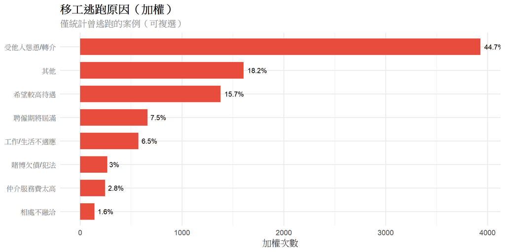

```r
df_runaway %>%
  filter(有勾選 == 1) %>%
  count(逃跑原因, wt = 權重, sort = TRUE) %>%
  mutate(pct = n / sum(n)) %>%
  ggplot(aes(x = reorder(逃跑原因, n), y = n)) +
  geom_col(fill = "#E74C3C", width = 0.7) +
  geom_text(aes(label = paste0(round(pct * 100, 1), "%")),
            hjust = -0.2, size = 3.5) +
  coord_flip() +
  labs(title = "移工逃跑原因（加權）",
       subtitle = "僅統計曾逃跑的案例（可複選）",
       x = NULL, y = "加權次數")
```

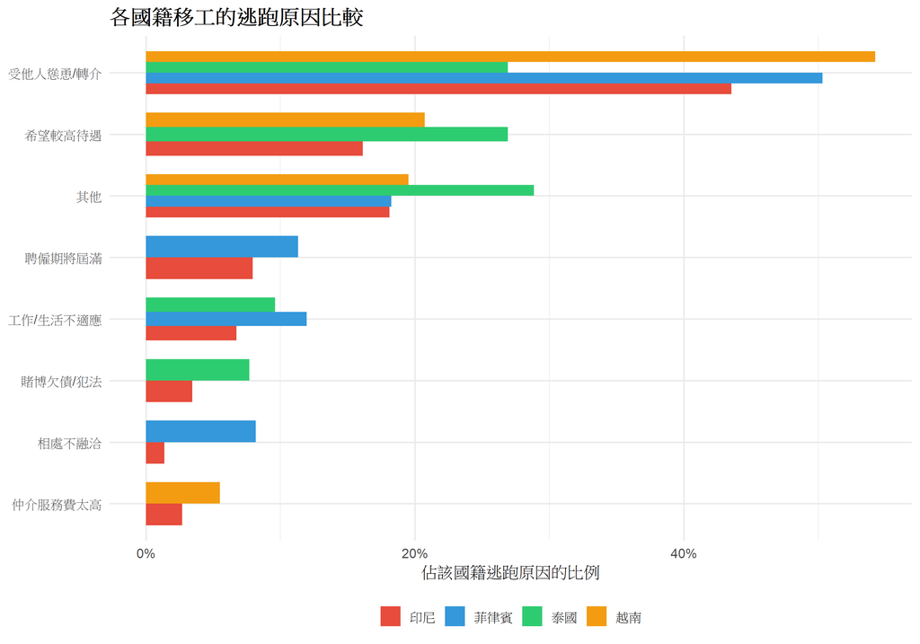

```r
df_runaway %>%
  filter(有勾選 == 1, !is.na(國籍)) %>%
  count(國籍, 逃跑原因, wt = 權重) %>%
  group_by(國籍) %>%
  mutate(pct = n / sum(n)) %>%
  ggplot(aes(x = reorder(逃跑原因, pct), y = pct, fill = 國籍)) +
  geom_col(position = "dodge", width = 0.7) +
  scale_fill_manual(values = pal_nation) +
  scale_y_continuous(labels = percent) +
  coord_flip() +
  labs(title = "各國籍移工的逃跑原因比較",
       x = NULL, y = "佔該國籍逃跑原因的比例") +
  theme(legend.title = element_blank())
```

# 4. 雇主困擾分析（是否存在偏見？）

> **核心問題：雇主對不同背景的移工是否有不同程度的困擾？**

## 4.1 困擾率：依國籍

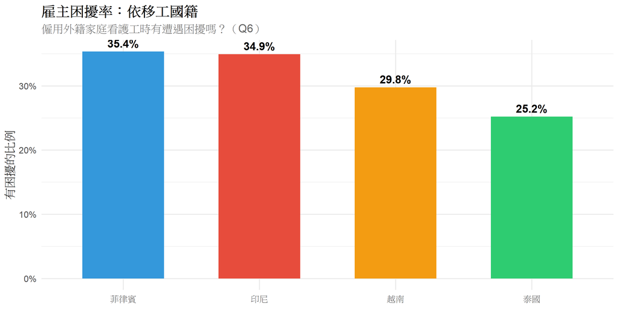

```r
df %>%
  filter(!is.na(國籍), !is.na(有困擾)) %>%
  count(國籍, 有困擾, wt = 權重) %>%
  group_by(國籍) %>%
  mutate(pct = n / sum(n)) %>%
  filter(有困擾 == "有") %>%
  ggplot(aes(x = reorder(國籍, -pct), y = pct, fill = 國籍)) +
  geom_col(width = 0.6, show.legend = FALSE) +
  geom_text(aes(label = percent(pct, accuracy = 0.1)),
            vjust = -0.5, fontface = "bold") +
  scale_fill_manual(values = pal_nation) +
  scale_y_continuous(labels = percent) +
  labs(title = "雇主困擾率：依移工國籍",
       subtitle = "僱用外籍家庭看護工時有遭遇困擾嗎？（Q6）",
       x = NULL, y = "有困擾的比例")
```

## 4.2 困擾類型：依國籍（交互作用）

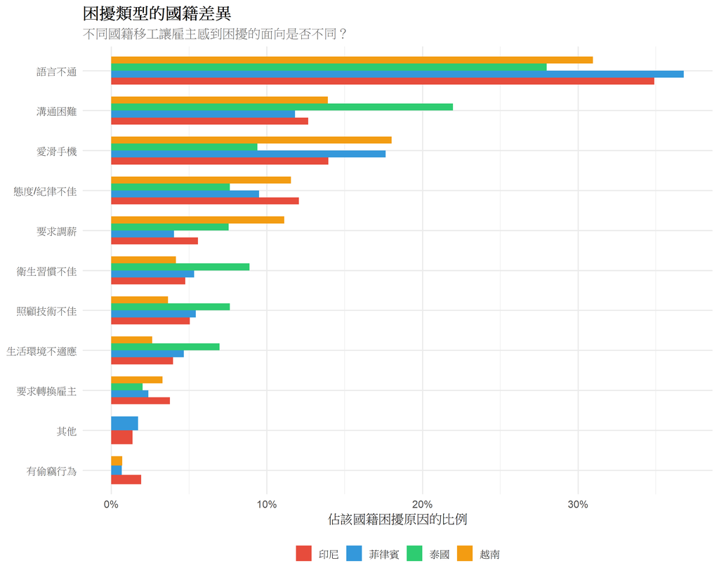

```r
df_trouble %>%
  filter(有勾選 == 1, !is.na(國籍)) %>%
  count(國籍, 困擾項目, wt = 權重) %>%
  group_by(國籍) %>%
  mutate(pct = n / sum(n)) %>%
  ggplot(aes(x = reorder(困擾項目, pct), y = pct, fill = 國籍)) +
  geom_col(position = "dodge", width = 0.7) +
  scale_fill_manual(values = pal_nation) +
  scale_y_continuous(labels = percent) +
  coord_flip() +
  labs(title = "困擾類型的國籍差異",
       subtitle = "不同國籍移工讓雇主感到困擾的面向是否不同？",
       x = NULL, y = "佔該國籍困擾原因的比例") +
  theme(legend.title = element_blank())
```

## 4.3 困擾率：國籍 × 教育程度（交互作用）

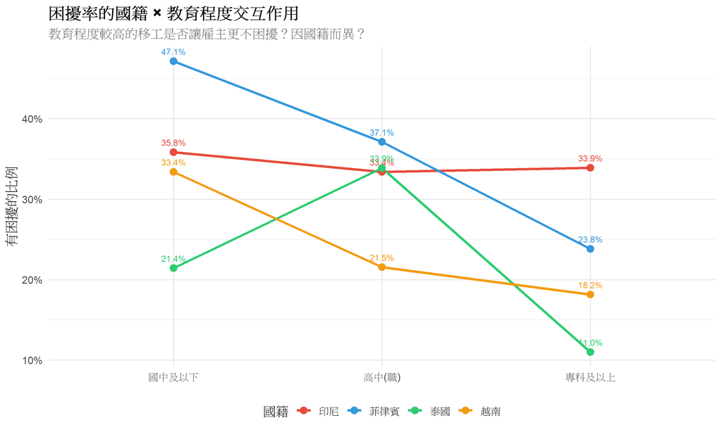

```r
df %>%
  filter(!is.na(國籍), !is.na(教育程度), !is.na(有困擾)) %>%
  count(國籍, 教育程度, 有困擾, wt = 權重) %>%
  group_by(國籍, 教育程度) %>%
  mutate(pct = n / sum(n)) %>%
  filter(有困擾 == "有") %>%
  ggplot(aes(x = 教育程度, y = pct, color = 國籍, group = 國籍)) +
  geom_line(linewidth = 1.2) +
  geom_point(size = 3) +
  geom_text(aes(label = percent(pct, accuracy = 0.1)),
            vjust = -1, size = 3, show.legend = FALSE) +
  scale_color_manual(values = pal_nation) +
  scale_y_continuous(labels = percent) +
  labs(title = "困擾率的國籍 × 教育程度交互作用",
       subtitle = "教育程度較高的移工是否讓雇主更不困擾？因國籍而異？",
       x = NULL, y = "有困擾的比例")
```

## 4.4 困擾的 Logistic 迴歸（含交互項）

```r
df <- df %>%
  mutate(困擾_二元 = ifelse(有困擾 == "有", 1, 0))

model_trouble <- glm(困擾_二元 ~ 國籍 * 性別 + 國籍 * 年齡組 + 教育程度 + 護理訓練 + 月薪,
                     data = df, family = binomial, weights = 權重)

tidy(model_trouble, conf.int = TRUE, exponentiate = TRUE) %>%
  mutate(across(where(is.numeric), ~ round(., 3))) %>%
  kable(caption = "雇主困擾 Logistic 迴歸 — 含交互項（勝算比 OR）")
```

雇主困擾 Logistic 迴歸 — 含交互項（勝算比 OR）

| term | estimate | std.error | statistic | p.value | conf.low | conf.high |
| --- | --- | --- | --- | --- | --- | --- |
| (Intercept) | 1.518 | 0.181 | 2.311 | 0.021 | 1.058 | 2.149 |
| 國籍菲律賓 | 0.129 | 0.698 | -2.929 | 0.003 | 0.025 | 0.425 |
| 國籍泰國 | 5.134 | 0.820 | 1.995 | 0.046 | 0.963 | 25.585 |
| 國籍越南 | 0.332 | 0.254 | -4.343 | 0.000 | 0.201 | 0.545 |
| 性別女 | 1.313 | 0.165 | 1.652 | 0.099 | 0.957 | 1.831 |
| 年齡組25-34歲 | 0.767 | 0.019 | -13.609 | 0.000 | 0.739 | 0.797 |
| 年齡組35-44歲 | 0.658 | 0.020 | -21.382 | 0.000 | 0.634 | 0.684 |
| 年齡組45歲以上 | 0.648 | 0.023 | -18.626 | 0.000 | 0.619 | 0.678 |
| 教育程度高中(職) | 0.819 | 0.011 | -17.947 | 0.000 | 0.802 | 0.837 |
| 教育程度專科及以上 | 0.642 | 0.024 | -18.188 | 0.000 | 0.612 | 0.673 |
| 護理訓練無 | 2.213 | 0.011 | 73.002 | 0.000 | 2.166 | 2.261 |
| 月薪 | 1.000 | 0.000 | -15.882 | 0.000 | 1.000 | 1.000 |
| 國籍菲律賓:性別女 | 0.929 | 0.210 | -0.348 | 0.728 | 0.613 | 1.401 |
| 國籍泰國:性別女 | 0.870 | 0.677 | -0.205 | 0.837 | 0.252 | 3.800 |
| 國籍越南:性別女 | 0.897 | 0.199 | -0.549 | 0.583 | 0.604 | 1.319 |
| 國籍菲律賓:年齡組25-34歲 | 9.113 | 0.667 | 3.311 | 0.001 | 3.007 | 46.291 |
| 國籍泰國:年齡組25-34歲 | 0.055 | 1.197 | -2.422 | 0.015 | 0.003 | 0.419 |
| 國籍越南:年齡組25-34歲 | 1.203 | 0.186 | 0.994 | 0.320 | 0.842 | 1.746 |
| 國籍菲律賓:年齡組35-44歲 | 10.867 | 0.667 | 3.576 | 0.000 | 3.589 | 55.178 |
| 國籍泰國:年齡組35-44歲 | 0.093 | 0.623 | -3.806 | 0.000 | 0.026 | 0.304 |
| 國籍越南:年齡組35-44歲 | 3.574 | 0.170 | 7.477 | 0.000 | 2.584 | 5.047 |
| 國籍菲律賓:年齡組45歲以上 | 9.099 | 0.668 | 3.307 | 0.001 | 3.000 | 46.236 |
| 國籍泰國:年齡組45歲以上 | 0.253 | 0.560 | -2.456 | 0.014 | 0.078 | 0.732 |
| 國籍越南:年齡組45歲以上 | 3.002 | 0.170 | 6.481 | 0.000 | 2.174 | 4.234 |

# 5. 雇主滿意度分析（偏見探測）

> **核心問題：雇主對不同國籍/性別/年齡的移工，滿意度是否有系統性差異？**

## 5.1 各面向平均滿意度

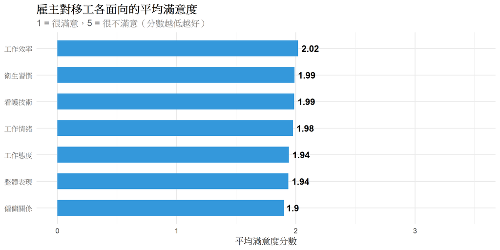

```r
df_sat %>%
  group_by(面向) %>%
  summarise(平均分數 = weighted.mean(滿意度分數, 權重, na.rm = TRUE),
            .groups = "drop") %>%
  ggplot(aes(x = reorder(面向, 平均分數), y = 平均分數)) +
  geom_col(fill = "#3498DB", width = 0.6) +
  geom_text(aes(label = round(平均分數, 2)), hjust = -0.2, fontface = "bold") +
  coord_flip() +
  scale_y_continuous(limits = c(0, 3.5)) +
  labs(title = "雇主對移工各面向的平均滿意度",
       subtitle = "1 = 很滿意，5 = 很不滿意（分數越低越好）",
       x = NULL, y = "平均滿意度分數")
```

## 5.2 滿意度：依國籍（雷達式比較）

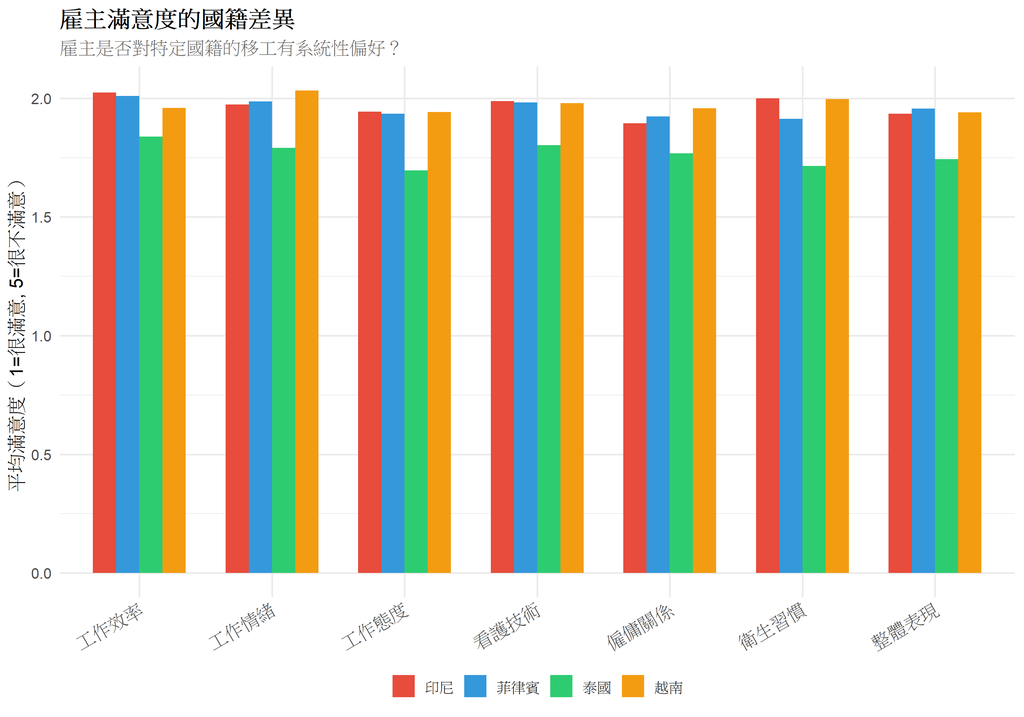

```r
df_sat %>%
  filter(!is.na(國籍)) %>%
  group_by(國籍, 面向) %>%
  summarise(平均分數 = weighted.mean(滿意度分數, 權重, na.rm = TRUE),
            .groups = "drop") %>%
  ggplot(aes(x = 面向, y = 平均分數, fill = 國籍)) +
  geom_col(position = "dodge", width = 0.7) +
  scale_fill_manual(values = pal_nation) +
  labs(title = "雇主滿意度的國籍差異",
       subtitle = "雇主是否對特定國籍的移工有系統性偏好？",
       x = NULL, y = "平均滿意度（1=很滿意, 5=很不滿意）") +
  theme(axis.text.x = element_text(angle = 30, hjust = 1),
        legend.title = element_blank())
```

## 5.3 滿意度熱力圖：國籍 × 面向

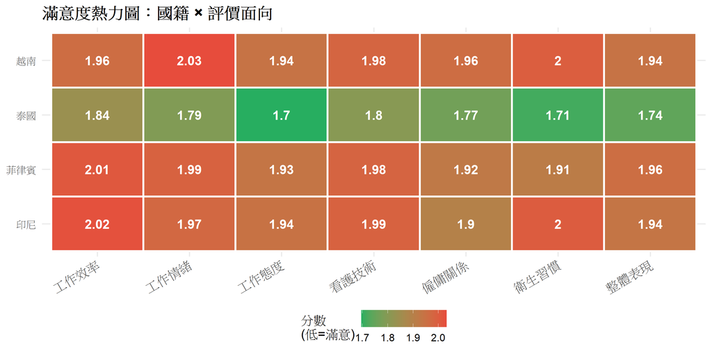

```r
df_sat %>%
  filter(!is.na(國籍)) %>%
  group_by(國籍, 面向) %>%
  summarise(平均分數 = weighted.mean(滿意度分數, 權重, na.rm = TRUE),
            .groups = "drop") %>%
  ggplot(aes(x = 面向, y = 國籍, fill = 平均分數)) +
  geom_tile(color = "white", linewidth = 1) +
  geom_text(aes(label = round(平均分數, 2)), color = "white", fontface = "bold") +
  scale_fill_gradient(low = "#27AE60", high = "#E74C3C",
                      name = "分數\n(低=滿意)") +
  labs(title = "滿意度熱力圖：國籍 × 評價面向",
       x = NULL, y = NULL) +
  theme(axis.text.x = element_text(angle = 30, hjust = 1))
```

## 5.4 滿意度：國籍 × 性別（交互作用）

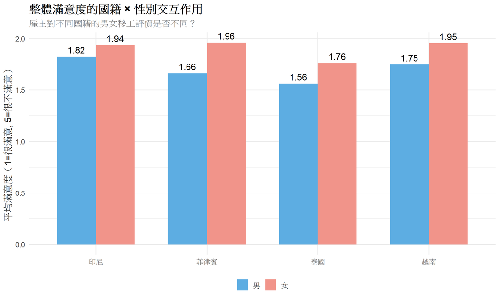

```r
df_sat %>%
  filter(!is.na(國籍), !is.na(性別), 面向 == "整體表現") %>%
  group_by(國籍, 性別) %>%
  summarise(平均分數 = weighted.mean(滿意度分數, 權重, na.rm = TRUE),
            n = n(), .groups = "drop") %>%
  ggplot(aes(x = 國籍, y = 平均分數, fill = 性別)) +
  geom_col(position = "dodge", width = 0.7) +
  geom_text(aes(label = round(平均分數, 2)),
            position = position_dodge(0.7), vjust = -0.5) +
  scale_fill_manual(values = pal_gender) +
  labs(title = "整體滿意度的國籍 × 性別交互作用",
       subtitle = "雇主對不同國籍的男女移工評價是否不同？",
       x = NULL, y = "平均滿意度（1=很滿意, 5=很不滿意）") +
  theme(legend.title = element_blank())
```

## 5.5 滿意度迴歸分析（含交互項）

```r
df_overall_sat <- df %>%
  mutate(整體滿意度 = as.numeric(q20_7))

model_sat <- lm(整體滿意度 ~ 國籍 * 性別 + 國籍 * 年齡組 + 教育程度 + 護理訓練 + 月薪,
                data = df_overall_sat, weights = 權重)

tidy(model_sat, conf.int = TRUE) %>%
  mutate(across(where(is.numeric), ~ round(., 3))) %>%
  kable(caption = "整體滿意度 OLS 迴歸 — 含交互項")
```

整體滿意度 OLS 迴歸 — 含交互項

| term | estimate | std.error | statistic | p.value | conf.low | conf.high |
| --- | --- | --- | --- | --- | --- | --- |
| (Intercept) | 2.701 | 0.389 | 6.944 | 0.000 | 1.938 | 3.464 |
| 國籍菲律賓 | 0.025 | 0.897 | 0.028 | 0.978 | -1.734 | 1.783 |
| 國籍泰國 | -0.238 | 1.639 | -0.145 | 0.885 | -3.451 | 2.975 |
| 國籍越南 | -0.002 | 0.494 | -0.003 | 0.997 | -0.970 | 0.966 |
| 性別女 | 0.069 | 0.352 | 0.196 | 0.845 | -0.622 | 0.760 |
| 年齡組25-34歲 | -0.023 | 0.046 | -0.511 | 0.610 | -0.113 | 0.066 |
| 年齡組35-44歲 | -0.125 | 0.046 | -2.726 | 0.006 | -0.214 | -0.035 |
| 年齡組45歲以上 | -0.163 | 0.054 | -3.024 | 0.003 | -0.269 | -0.057 |
| 教育程度高中(職) | -0.117 | 0.025 | -4.671 | 0.000 | -0.166 | -0.068 |
| 教育程度專科及以上 | -0.235 | 0.053 | -4.465 | 0.000 | -0.339 | -0.132 |
| 護理訓練無 | 0.325 | 0.026 | 12.675 | 0.000 | 0.275 | 0.375 |
| 月薪 | 0.000 | 0.000 | -4.952 | 0.000 | 0.000 | 0.000 |
| 國籍菲律賓:性別女 | 0.154 | 0.450 | 0.342 | 0.733 | -0.728 | 1.035 |
| 國籍泰國:性別女 | 0.003 | 1.205 | 0.002 | 0.998 | -2.360 | 2.365 |
| 國籍越南:性別女 | -0.044 | 0.412 | -0.107 | 0.915 | -0.853 | 0.765 |
| 國籍菲律賓:年齡組25-34歲 | -0.135 | 0.785 | -0.172 | 0.863 | -1.674 | 1.404 |
| 國籍泰國:年齡組25-34歲 | 0.050 | 1.875 | 0.027 | 0.979 | -3.626 | 3.726 |
| 國籍越南:年齡組25-34歲 | -0.213 | 0.332 | -0.640 | 0.522 | -0.864 | 0.438 |
| 國籍菲律賓:年齡組35-44歲 | -0.035 | 0.784 | -0.045 | 0.964 | -1.572 | 1.501 |
| 國籍泰國:年齡組35-44歲 | 0.474 | 1.311 | 0.361 | 0.718 | -2.096 | 3.043 |
| 國籍越南:年齡組35-44歲 | 0.092 | 0.309 | 0.298 | 0.766 | -0.515 | 0.699 |
| 國籍菲律賓:年齡組45歲以上 | -0.051 | 0.786 | -0.065 | 0.948 | -1.592 | 1.490 |
| 國籍泰國:年齡組45歲以上 | 0.318 | 1.261 | 0.252 | 0.801 | -2.154 | 2.790 |
| 國籍越南:年齡組45歲以上 | 0.199 | 0.307 | 0.650 | 0.516 | -0.402 | 0.801 |

```r
cat("\n===== 模型摘要 =====\n")
```

```
##
## ===== 模型摘要 =====
```

```r
glance(model_sat) %>%
  select(r.squared, adj.r.squared, AIC, BIC, nobs) %>%
  kable(caption = "模型配適度", digits = 3)
```

模型配適度

| r.squared | adj.r.squared | AIC | BIC | nobs |
| --- | --- | --- | --- | --- |
| 0.059 | 0.053 | 9370.188 | 9527.639 | 4016 |

# 6. 勞動條件與薪資分析

## 6.1 月薪分布：依國籍

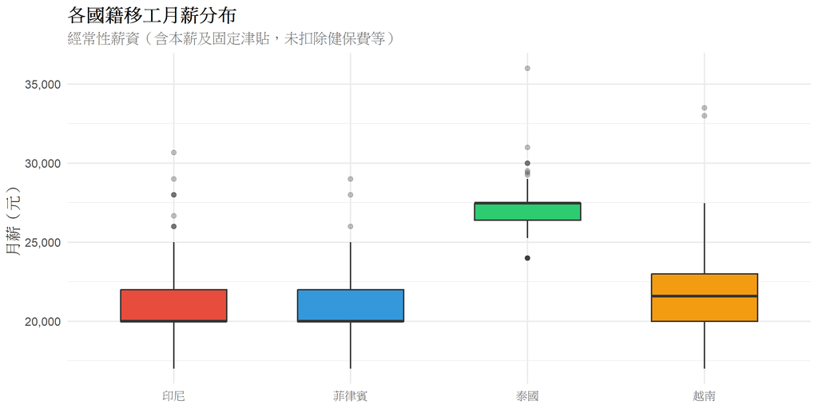

```r
df %>%
  filter(!is.na(國籍), !is.na(月薪), 月薪 > 0, 月薪 < 80000) %>%
  ggplot(aes(x = 國籍, y = 月薪, fill = 國籍)) +
  geom_boxplot(width = 0.6, outlier.alpha = 0.3, show.legend = FALSE) +
  scale_fill_manual(values = pal_nation) +
  scale_y_continuous(labels = comma) +
  labs(title = "各國籍移工月薪分布",
       subtitle = "經常性薪資（含本薪及固定津貼，未扣除健保費等）",
       x = NULL, y = "月薪（元）")
```

## 6.2 月薪：國籍 × 教育程度

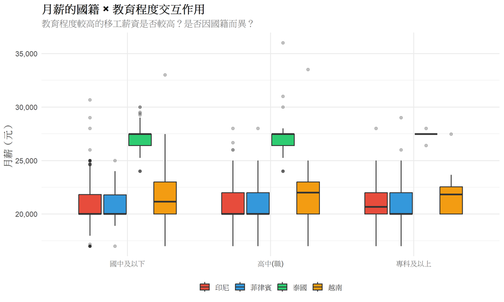

```r
df %>%
  filter(!is.na(國籍), !is.na(教育程度), !is.na(月薪),
         月薪 > 0, 月薪 < 80000) %>%
  ggplot(aes(x = 教育程度, y = 月薪, fill = 國籍)) +
  geom_boxplot(width = 0.7, outlier.alpha = 0.3) +
  scale_fill_manual(values = pal_nation) +
  scale_y_continuous(labels = comma) +
  labs(title = "月薪的國籍 × 教育程度交互作用",
       subtitle = "教育程度較高的移工薪資是否較高？是否因國籍而異？",
       x = NULL, y = "月薪（元）") +
  theme(legend.title = element_blank())
```

## 6.3 每日工時：依國籍

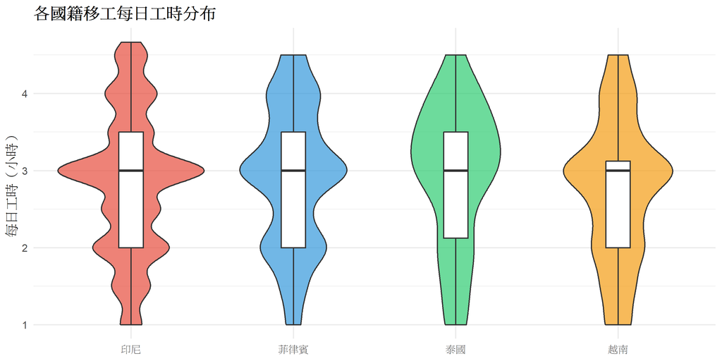

```r
df %>%
  filter(!is.na(國籍), !is.na(每日工時), 每日工時 > 0, 每日工時 <= 24) %>%
  ggplot(aes(x = 國籍, y = 每日工時, fill = 國籍)) +
  geom_violin(alpha = 0.7, show.legend = FALSE) +
  geom_boxplot(width = 0.15, fill = "white", outlier.shape = NA) +
  scale_fill_manual(values = pal_nation) +
  labs(title = "各國籍移工每日工時分布",
       x = NULL, y = "每日工時（小時）")
```

## 6.4 放假情形：依國籍

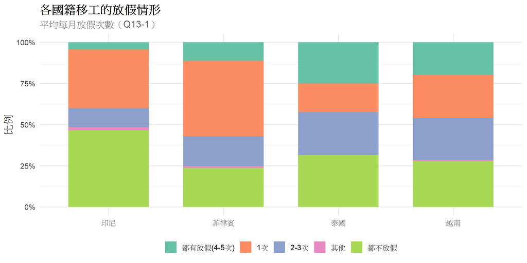

```r
df %>%
  filter(!is.na(國籍), !is.na(放假情形)) %>%
  count(國籍, 放假情形, wt = 權重) %>%
  group_by(國籍) %>%
  mutate(pct = n / sum(n)) %>%
  ggplot(aes(x = 國籍, y = pct, fill = 放假情形)) +
  geom_col(width = 0.7) +
  scale_y_continuous(labels = percent) +
  scale_fill_brewer(palette = "Set2") +
  labs(title = "各國籍移工的放假情形",
       subtitle = "平均每月放假次數（Q13-1）",
       x = NULL, y = "比例") +
  theme(legend.title = element_blank())
```

## 6.5 薪資明細提供：依國籍

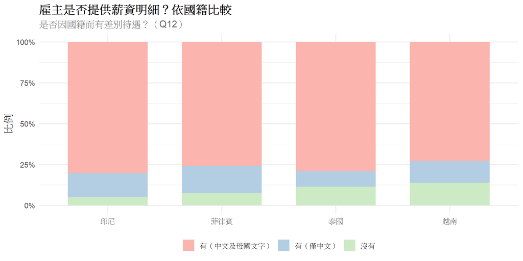

```r
df %>%
  filter(!is.na(國籍), !is.na(薪資明細)) %>%
  count(國籍, 薪資明細, wt = 權重) %>%
  group_by(國籍) %>%
  mutate(pct = n / sum(n)) %>%
  ggplot(aes(x = 國籍, y = pct, fill = 薪資明細)) +
  geom_col(width = 0.7) +
  scale_y_continuous(labels = percent) +
  scale_fill_brewer(palette = "Pastel1") +
  labs(title = "雇主是否提供薪資明細？依國籍比較",
       subtitle = "是否因國籍而有差別待遇？（Q12）",
       x = NULL, y = "比例") +
  theme(legend.title = element_blank())
```

# 7. 政策態度與雇主行為

## 7.1 願意讓移工休假：依國籍

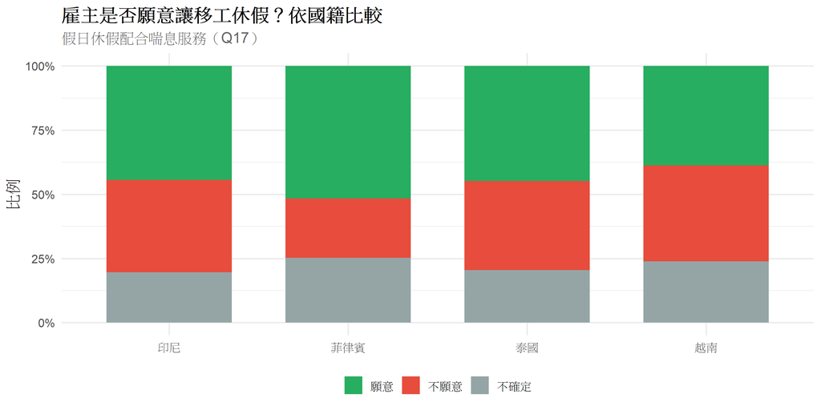

```r
df %>%
  filter(!is.na(國籍), !is.na(願意休假)) %>%
  count(國籍, 願意休假, wt = 權重) %>%
  group_by(國籍) %>%
  mutate(pct = n / sum(n)) %>%
  ggplot(aes(x = 國籍, y = pct, fill = 願意休假)) +
  geom_col(width = 0.7) +
  scale_y_continuous(labels = percent) +
  scale_fill_manual(values = c("願意" = "#27AE60",
                                "不願意" = "#E74C3C",
                                "不確定" = "#95A5A6")) +
  labs(title = "雇主是否願意讓移工休假？依國籍比較",
       subtitle = "假日休假配合喘息服務（Q17）",
       x = NULL, y = "比例") +
  theme(legend.title = element_blank())
```

## 7.2 意外保險：依國籍 × 家庭經濟

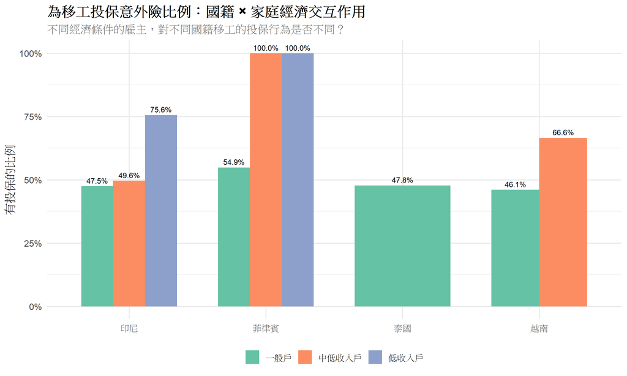

```r
df %>%
  filter(!is.na(國籍), !is.na(有保險), !is.na(家庭經濟)) %>%
  count(國籍, 家庭經濟, 有保險, wt = 權重) %>%
  group_by(國籍, 家庭經濟) %>%
  mutate(pct = n / sum(n)) %>%
  filter(有保險 == "有") %>%
  ggplot(aes(x = 國籍, y = pct, fill = 家庭經濟)) +
  geom_col(position = "dodge", width = 0.7) +
  geom_text(aes(label = percent(pct, accuracy = 0.1)),
            position = position_dodge(0.7), vjust = -0.5, size = 3) +
  scale_y_continuous(labels = percent) +
  scale_fill_brewer(palette = "Set2") +
  labs(title = "為移工投保意外險比例：國籍 × 家庭經濟交互作用",
       subtitle = "不同經濟條件的雇主，對不同國籍移工的投保行為是否不同？",
       x = NULL, y = "有投保的比例") +
  theme(legend.title = element_blank())
```

## 7.3 願意參加講習：依國籍 × 教育程度

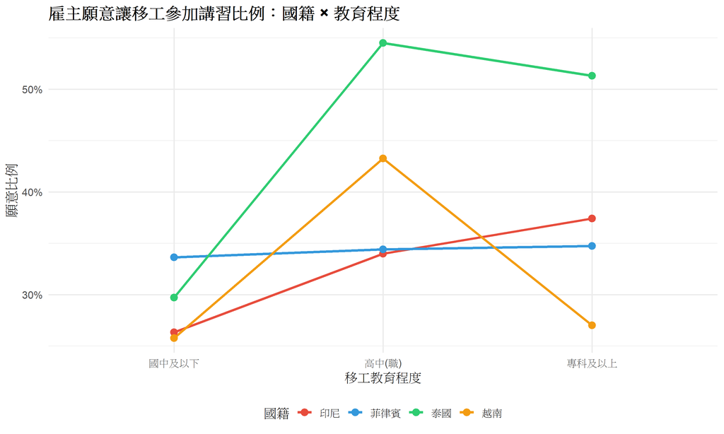

```r
df %>%
  filter(!is.na(國籍), !is.na(教育程度), !is.na(願意講習)) %>%
  count(國籍, 教育程度, 願意講習, wt = 權重) %>%
  group_by(國籍, 教育程度) %>%
  mutate(pct = n / sum(n)) %>%
  filter(願意講習 == "願意") %>%
  ggplot(aes(x = 教育程度, y = pct, color = 國籍, group = 國籍)) +
  geom_line(linewidth = 1.2) +
  geom_point(size = 3) +
  scale_color_manual(values = pal_nation) +
  scale_y_continuous(labels = percent) +
  labs(title = "雇主願意讓移工參加講習比例：國籍 × 教育程度",
       x = "移工教育程度", y = "願意比例")
```

# 8. 綜合交互作用摘要

> 以下整合前面分析結果，產出一張**綜合比較表**，方便快速瀏覽各交互效果。

## 8.1 馬賽克圖：逃跑 × 國籍 × 性別

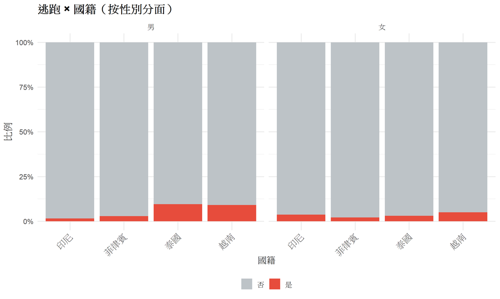

```r
df %>%
  filter(!is.na(國籍), !is.na(性別), !is.na(曾逃跑)) %>%
  ggplot(aes(x = 國籍, fill = 曾逃跑)) +
  geom_bar(position = "fill") +
  facet_wrap(~ 性別) +
  scale_fill_manual(values = c("否" = "#BDC3C7", "是" = "#E74C3C")) +
  scale_y_continuous(labels = scales::percent) +
  labs(title = "逃跑 × 國籍（按性別分面）",
       x = "國籍", y = "比例") +
  theme(axis.text.x = element_text(angle = 45, hjust = 1),
        legend.title = element_blank())
```

## 8.2 馬賽克圖：困擾 × 國籍 × 護理訓練

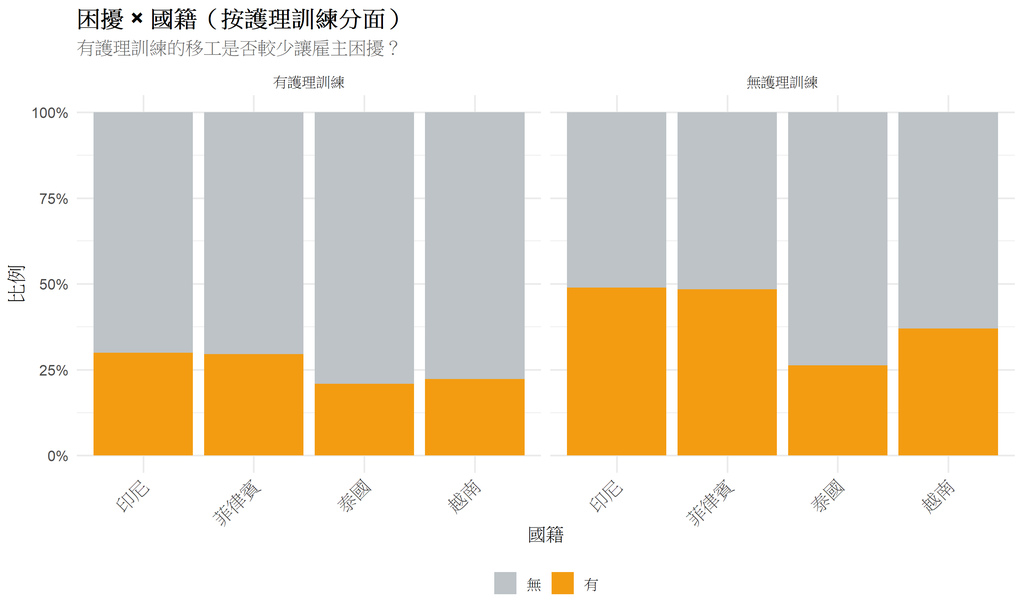

```r
df %>%
  filter(!is.na(國籍), !is.na(護理訓練), !is.na(有困擾)) %>%
  ggplot(aes(x = 國籍, fill = 有困擾)) +
  geom_bar(position = "fill") +
  facet_wrap(~ 護理訓練,
             labeller = labeller(護理訓練 = c("有" = "有護理訓練",
                                             "無" = "無護理訓練"))) +
  scale_fill_manual(values = c("無" = "#BDC3C7", "有" = "#F39C12")) +
  scale_y_continuous(labels = scales::percent) +
  labs(title = "困擾 × 國籍（按護理訓練分面）",
       subtitle = "有護理訓練的移工是否較少讓雇主困擾？",
       x = "國籍", y = "比例") +
  theme(axis.text.x = element_text(angle = 45, hjust = 1),
        legend.title = element_blank())
```

## 8.3 卡方獨立性檢定摘要

```r
# 準備一個函式來執行加權卡方檢定（使用未加權資料近似）
run_chisq <- function(var1, var2, label) {
  tbl <- table(var1, var2)
  test <- chisq.test(tbl, simulate.p.value = TRUE)
  tibble(
    比較組合 = label,
    卡方值 = round(test$statistic, 2),
    自由度 = test$parameter,
    p值 = format.pval(test$p.value, digits = 3),
    顯著 = ifelse(test$p.value < 0.05, "✓", "")
  )
}

# 執行多組檢定
chisq_results <- bind_rows(
  run_chisq(df$國籍, df$曾逃跑, "國籍 × 逃跑"),
  run_chisq(df$性別, df$曾逃跑, "性別 × 逃跑"),
  run_chisq(df$年齡組, df$曾逃跑, "年齡組 × 逃跑"),
  run_chisq(df$教育程度, df$曾逃跑, "教育程度 × 逃跑"),
  run_chisq(df$護理訓練, df$曾逃跑, "護理訓練 × 逃跑"),
  run_chisq(df$國籍, df$有困擾, "國籍 × 困擾"),
  run_chisq(df$性別, df$有困擾, "性別 × 困擾"),
  run_chisq(df$國籍, df$願意休假, "國籍 × 願意休假"),
  run_chisq(df$國籍, df$有保險, "國籍 × 有保險"),
  run_chisq(df$國籍, df$薪資明細, "國籍 × 薪資明細")
)

kable(chisq_results, caption = "卡方獨立性檢定摘要表")
```

卡方獨立性檢定摘要表

| 比較組合 | 卡方值 | 自由度 | p值 | 顯著 |
| --- | --- | --- | --- | --- |
| 國籍 × 逃跑 | 8.55 | NA | 0.04 | ✓ |
| 性別 × 逃跑 | 1.66 | NA | 0.214 |  |
| 年齡組 × 逃跑 | 5.35 | NA | 0.149 |  |
| 教育程度 × 逃跑 | 5.38 | NA | 0.069 |  |
| 護理訓練 × 逃跑 | 6.83 | NA | 0.0105 | ✓ |
| 國籍 × 困擾 | 14.29 | NA | 0.001 | ✓ |
| 性別 × 困擾 | 10.55 | NA | 5e-04 | ✓ |
| 國籍 × 願意休假 | 28.01 | NA | 5e-04 | ✓ |
| 國籍 × 有保險 | 6.92 | NA | 0.073 |  |
| 國籍 × 薪資明細 | 38.99 | NA | 5e-04 | ✓ |

# 9. 後續分析建議

以上分析已涵蓋描述統計、視覺化、交叉分析、迴歸模型與統計檢定。以下提供進一步分析的方向：

```r
cat("
### 可延伸的進階分析方向

**1. 多層次模型（Multilevel Model）**
- 變項 `j1` 為縣市代碼，可作為第二層分組變項
- 探討縣市層級的脈絡效果（如：都會區 vs. 非都會區的雇主行為差異）

**2. 結構方程模型（SEM）**
- 將 Q20 七項滿意度指標視為潛在因素
- 檢視國籍、性別、教育程度對潛在滿意度的影響路徑

**3. 傾向分數配對（Propensity Score Matching）**
- 控制移工背景差異後，比較不同國籍移工的逃跑率
- 更嚴謹地估計「國籍效應」

**4. 地理空間分析**
- 結合 `j1` 縣市代碼，繪製逃跑率 / 困擾率的地理熱力圖
- 探討區域勞動市場特性的影響

**5. 文字探勘**
- 若有開放題回答資料，可進行文字雲、情感分析
- 比較不同國籍移工相關的雇主敘述用語差異

**6. 時間序列比較**
- 若有歷年資料（如 110、111、112 年），可追蹤趨勢變化
- 觀察政策介入（如直聘制度推廣）對行為的影響
")
```

### 可延伸的進階分析方向

**1. 多層次模型（Multilevel Model）** - 變項 `j1` 為縣市代碼，可作為第二層分組變項 - 探討縣市層級的脈絡效果（如：都會區 vs. 非都會區的雇主行為差異）

**2. 結構方程模型（SEM）** - 將 Q20 七項滿意度指標視為潛在因素 - 檢視國籍、性別、教育程度對潛在滿意度的影響路徑

**3. 傾向分數配對（Propensity Score Matching）** - 控制移工背景差異後，比較不同國籍移工的逃跑率 - 更嚴謹地估計「國籍效應」

**4. 地理空間分析** - 結合 `j1` 縣市代碼，繪製逃跑率 / 困擾率的地理熱力圖 - 探討區域勞動市場特性的影響

**5. 文字探勘** - 若有開放題回答資料，可進行文字雲、情感分析 - 比較不同國籍移工相關的雇主敘述用語差異

**6. 時間序列比較** - 若有歷年資料（如 110、111、112 年），可追蹤趨勢變化 - 觀察政策介入（如直聘制度推廣）對行為的影響

*本報告由 R Markdown 自動生成，資料來源：勞動部「移工管理及運用調查」113年家庭面問卷*